# PracticalMachineLearning-Quiz4

Mona Habibi

June 17, 2017

# Background

Using devices such as Jawbone Up, Nike FuelBand, and Fitbit it is now possible to collect a large amount of data about personal activity relatively inexpensively. These type of devices are part of the quantified self movement - a group of enthusiasts who take measurements about themselves regularly to improve their health, to find patterns in their behavior, or because they are tech geeks. One thing that people regularly do is quantify how much of a particular activity they do, but they rarely quantify how well they do it. In this project, your goal will be to use data from accelerometers on the belt, forearm, arm, and dumbell of 6 participants. They were asked to perform barbell lifts correctly and incorrectly in 5 different ways. More information is available from the website here: http://groupware.les.inf.puc-rio.br/har (see the section on the Weight Lifting Exercise Dataset).

# Uploading the libraries

```r
library(AppliedPredictiveModeling)
library(caret)
library(rpart)
```

```r
library(rpart.plot)
library(rattle)
library(randomForest)
library(corrplot)
set.seed(20001)
```

# Data

The training data for this project are available here: [https://d396qusza40orc.cloudfront.net/predmachlearn/pml-training.csv]

The test data are available here: [https://d396qusza40orc.cloudfront.net/predmachlearn/pml-testing.csv]

The data for this project come from this source: [http://groupware.les.inf.puc-rio.br/har].

```r
TrainUrl <- "https://d396qusza40orc.cloudfront.net/predmachlearn/pml-training.csv"
TestUrl  <- "https://d396qusza40orc.cloudfront.net/predmachlearn/pml-testing.csv"
trainingdata <-read.csv("pml-training.csv", na.strings = c("NA", "", "#DIV0!"))
testingdata <-read.csv("pml-testing.csv", na.strings = c("NA", "", "#DIV0!"))
```

```r
trainingdata<-trainingdata[,colSums(is.na(trainingdata)) == 0]
testingdata<-testingdata[,colSums(is.na(testingdata)) == 0]

trainingdata<- trainingdata[,-c(1:7)]
testingdata<- testingdata[,-c(1:7)]
```

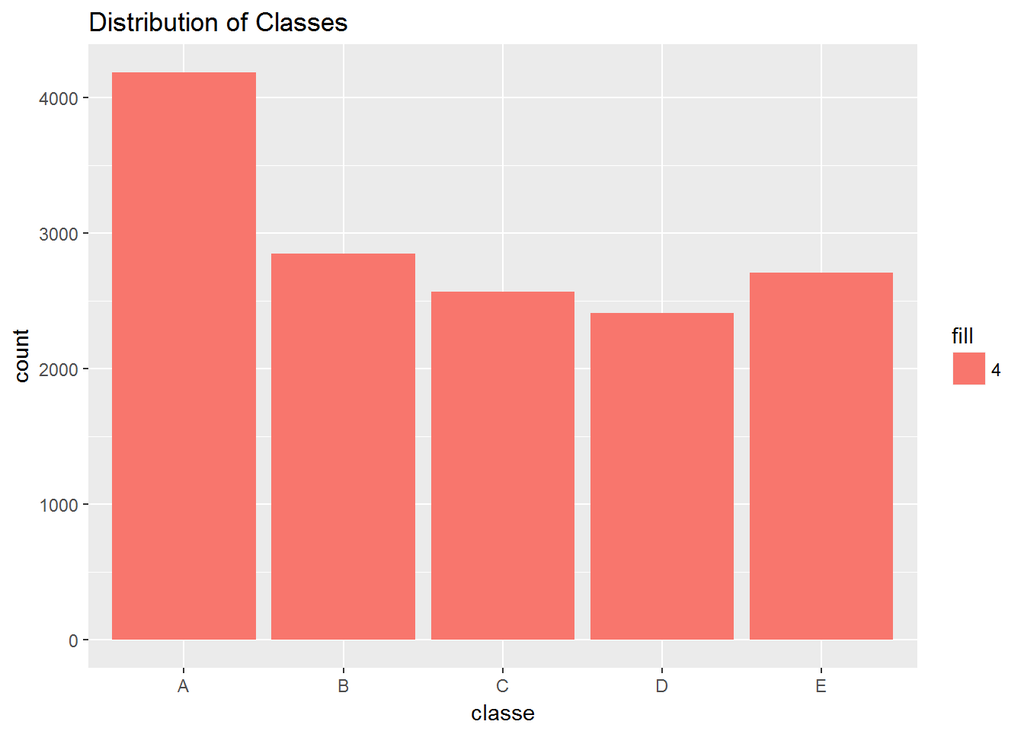

```r
inTrain <- createDataPartition(y=trainingdata$classe, p=0.75, list=FALSE)
training<-trainingdata[inTrain,]
testing<-trainingdata[-inTrain,]
qplot(classe, fill = "4", data=training, main="Distribution of Classes")
```

# Model fitting

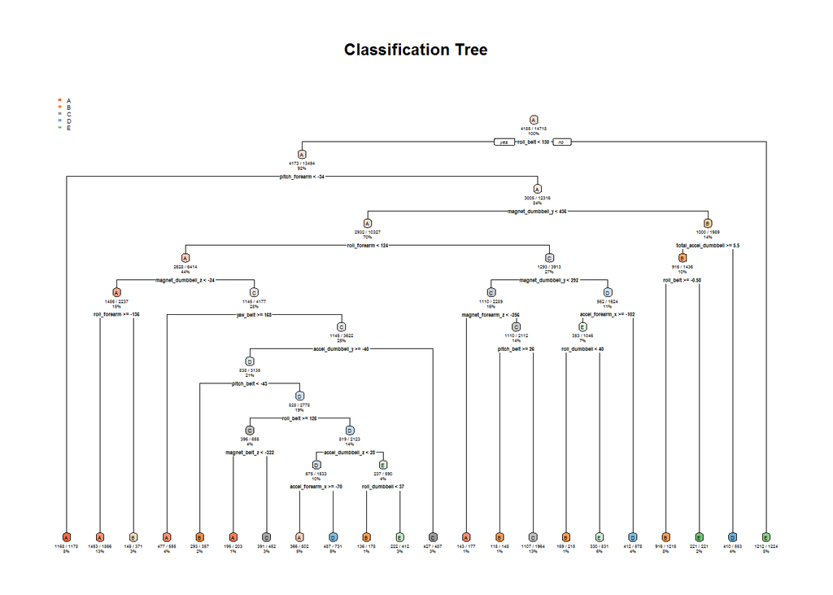

```r
modelDt <- rpart(classe ~ ., data=training, method="class")
prediction_Dt <- predict(modelDt, testing, type = "class")
rpart.plot(modelDt, main="Classification Tree", extra=102, under=TRUE)
```

```r
confusionMatrix(prediction_Dt, testing$classe)
```

```
## Confusion Matrix and Statistics
##
##           Reference
## Prediction    A    B    C    D    E
##          A 1260  174   55   96   28
##          B   60  558   42   58   60
##          C   33   70  650  125  117
##          D   22   75   62  427   34
##          E   20   72   46   98  662
##
## Overall Statistics
##
##                Accuracy : 0.7253
##                  95% CI : (0.7126, 0.7378)
##     No Information Rate : 0.2845
##     P-Value [Acc > NIR] : < 2.2e-16
##
##                   Kappa : 0.6505
##  Mcnemar's Test P-Value : < 2.2e-16
##
## Statistics by Class:
##
##                      Class: A Class: B Class: C Class: D Class: E
## Sensitivity            0.9032   0.5880   0.7602  0.53109   0.7347
## Specificity            0.8994   0.9444   0.9148  0.95293   0.9410
## Pos Pred Value         0.7812   0.7172   0.6533  0.68871   0.7372
## Neg Pred Value         0.9590   0.9052   0.9476  0.91200   0.9403
## Prevalence             0.2845   0.1935   0.1743  0.16395   0.1837
## Detection Rate         0.2569   0.1138   0.1325  0.08707   0.1350
## Detection Prevalence   0.3289   0.1586   0.2029  0.12643   0.1831
## Balanced Accuracy      0.9013   0.7662   0.8375  0.74201   0.8379
```

The accurace of the decision tree model is 0.72. Next, we try the random forest model.

## Random forest

```r
modelRf <- train(classe ~ ., data=training, method="rf", na.action=na.omit)
modelRf
```

```
## Random Forest
##
## 14718 samples
##    52 predictor
##     5 classes: 'A', 'B', 'C', 'D', 'E'
##
## No pre-processing
## Resampling: Bootstrapped (25 reps)
## Summary of sample sizes: 14718, 14718, 14718, 14718, 14718, 14718, ...
## Resampling results across tuning parameters:
##
##   mtry  Accuracy   Kappa
##    2    0.9889734  0.9860559
##   27    0.9891745  0.9863102
##   52    0.9810103  0.9759868
##
## Accuracy was used to select the optimal model using  the largest value.
## The final value used for the model was mtry = 27.
```

```r
predict_Rf <- predict(modelRf, testing)
confusionMatrix(testing$classe, predict_Rf)
```

```
## Confusion Matrix and Statistics
##
##           Reference
## Prediction    A    B    C    D    E
##          A 1391    2    1    0    1
##          B    7  942    0    0    0
##          C    0    4  849    2    0
##          D    0    0   13  790    1
##          E    0    1    1    0  899
##
## Overall Statistics
##
##                Accuracy : 0.9933
##                  95% CI : (0.9906, 0.9954)
##     No Information Rate : 0.2851
##     P-Value [Acc > NIR] : < 2.2e-16
##
##                   Kappa : 0.9915
##  Mcnemar's Test P-Value : NA
##
## Statistics by Class:
##
##                      Class: A Class: B Class: C Class: D Class: E
## Sensitivity            0.9950   0.9926   0.9826   0.9975   0.9978
## Specificity            0.9989   0.9982   0.9985   0.9966   0.9995
## Pos Pred Value         0.9971   0.9926   0.9930   0.9826   0.9978
## Neg Pred Value         0.9980   0.9982   0.9963   0.9995   0.9995
## Prevalence             0.2851   0.1935   0.1762   0.1615   0.1837
## Detection Rate         0.2836   0.1921   0.1731   0.1611   0.1833
## Detection Prevalence   0.2845   0.1935   0.1743   0.1639   0.1837
## Balanced Accuracy      0.9969   0.9954   0.9906   0.9970   0.9986
```

## Test set prediction

The cross validation accuracy is 0.99 , that is saying the random forest model model performs much better tha tree decision model. Therefore, we pick random forest prediction to validiate the testing data set.

```r
predict_Rftest <- predict(modelRf, testingdata)
predict_Rftest
```

```
##  [1] B A B A A E D B A A B C B A E E A B B B
## Levels: A B C D E
```

[output not shown]